# Lecture #13

난수를 사용한 평균의 분포에 대한 모의실험

Junho Ahn

2022-09-08

## 정규분포에서의 평균의 분포

### 정규분포에서의 평균

**가정**  
$n$개의 자료 $X_1, X_2, ... , X_n$가 모두 독립이고 기댓값이 $\mu$이고 분산이 $\sigma^2$인 정규분포

**표본평균 $\bar X$의 분포**  
- 기댓값은 $\mu$, 분산은 $\frac{\sigma^2}{n}$인 정규분포  
- 기댓값은 변함이 없음  
- 분산은 작아짐

### 모의실험을 이용한 평균의 분포 확인

#### 모의실험1

(평균에 대한 모의실험)  
1. 10개의 표준정규분포에서의 난수의 평균을 계산하는 것을  
2. 100번 반복하여 100개의 평균을 얻어  
3. 이들 평균의 평균과 분산을 계산해보자. 이 값이 0과 1/10에 근접하는지 확인

```r
meannorm <- function(n=10, nrep=100) {
  mx <- rep(0, nrep) # mx를 nrep개의 표본평균으로 저장할 벡터로 사용하며 초기값으로 0을 설정
  for(i in 1:nrep){ # for 반복문은 n개의 표준정규분포에서의 난수생성, 이의 평균을 mx에 저장
    x <- rnorm(n)
    mx[i] <- mean(x)
  } # end for
  list(mmx=mean(mx), sdmx=var(mx)) # list명령으로 평균과 표준편차의 값을 출력으로 얻음
} # end function
```

함수 호출결과

```r
meannorm()
```

```
## $mmx
## [1] 0.01046325
##
## $sdmx
## [1] 0.08195617
```

평균을 1000번 얻어 이들의 평균과 표준편차를 반복한 결과

```r
meannorm(n=10, nrep=1000)
```

```
## $mmx
## [1] 0.003740415
##
## $sdmx
## [1] 0.103191
```

비슷한 결과를 얻을 수 있음

#### 모의실험2

(정규분포에서 표본평균의 분포)  
정규분포의 표본평뉵이 정규분포인지 확인하기 위해  
1. 정규분포 난수를 사용하여 표본평균의 값을 모의실험으로 생성하고  
2. 이들 표봉평균에 대한 히스토그램을 그려보자

```r
meanhist <- function(n=10, nrep=100) {
  mx <- rep(0, nrep) # mx를 nrep개의 표본평균으로 저장할 벡터로 사용하며 초기값으로 0을 설정
  for(i in 1:nrep){ # for 반복문은 n개의 표준정규분포에서의 난수생성, 이의 평균을 mx에 저장
    x <- rnorm(n)
    mx[i] <- mean(x)
  } # end for
  hist(mx, prob = T) #nrep개의 평균을 얻은 다음 mx로 히스토그램을 그림
  lines(xx <- seq(-3,3,by=0.02), dnorm(xx, 0, sqrt(1/n)), col = "red") # line함수는 정규분포의 곡선을 추가하는 명령
} # end function
```

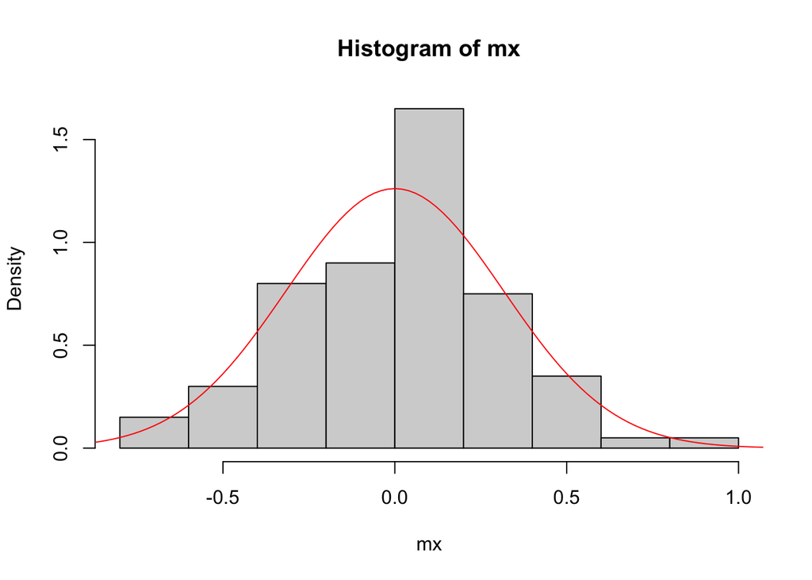

```r
meanhist()
```

정규분포와 가까운 것을 확인할 수 있음

## 이항분포의 정규근사

### 이항분포와 정규분포의 근사

**자료 $X$**  
$n$개 중에서 성공의개수인 $X$의 분포가 성공확률 $p$인 이항분포인 경우

$X$의 분포  
- 기댓값 $np$, 분산 $np(1-p)$인 정규분포로 근사할 수 있음 ($n$이 충분히 클 때)  
- 이를 **이항분포의 정규근사**라고 함

### 모의실험을 이용한 이항분포의 정규근사 확인

(이항분포의 정규근사) 이항분포의 겅규근사를 모의실험으로 확인해 보기로 한다.

```r
norm.binorm <- function(ndata=1000, nn=100, p=0.5) {
  #--------------------------------------------------------------
  # B(nn,p)에서 ndata개의 난수를 생성하여 이를 N(np, npq)와 비교
  # B(nn,p)의 확률 히스토그램과 정규분포의 pdf그림
  #---------------------------------------------------------------
  x <- rbinom(ndata, nn, p)
  substr <- paste("n=", as.character(nn), ", p=", as.character(p), sep = "")
  hist(x, prob=TRUE, main="B(n,p)와 N(np, nqp)의 비교", sub = substr)

  mx <- nn*p
  sdx <- sqrt(nn*p*(1-p))
  xmin <- min(x)
  xmax <- max(x)
  xx <- seq(from=xmin, to=xmax, length.out=100)
  lines(xx, dnorm(xx, mx, sdx))
} #end function
```

**함수설명**

- x에 이항분포에서의 난수를 ndata 개수만큼 생성하여 저장함
- hist 함수로 이에 대한 히스토그램을 그림: 이 때 주제목과 보조제목(substr)을 설정함
- 히스토그램을 정규분포에 비교하기 위해 평균을 mx, 표준편차를 sdx라고 하였음
- 정규분포 곡선을 겹쳐 그리기 위해 자료 중 최소와 최대를 얻어 이 사이에 100개의 값을 얻어 xx라고 하였음.
- xx에서의 dnorm값을 얻어 정규분포 xx에서 정규분포의 확률밀도함수를 계산하였음
- 마지막으로 `lines()` 함수를 사용하여 정규분포 곡선을 히스토그램에 겹쳐 그렸음

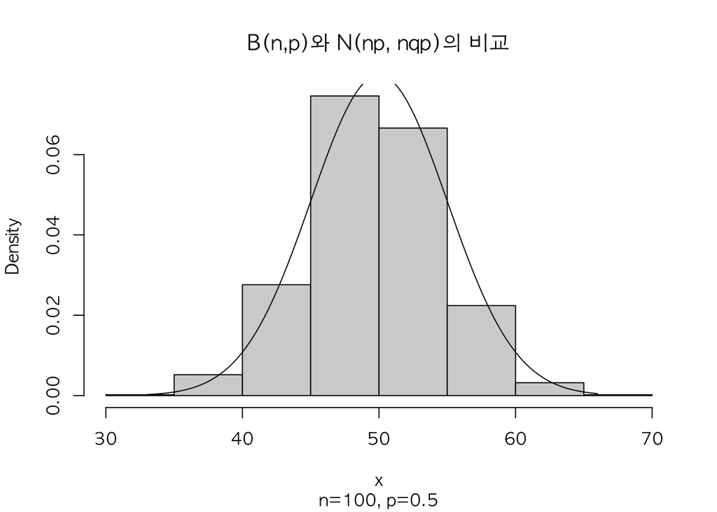

```r
par(family = "AppleGothic")
norm.binorm()
```